# R 고급 통계분석 1일차 (6)

Sanghoo Yoon

# 데이터 전처리

[figure not shown]

참고교재 : 시작하세요! 데이터분석 with R

## 분산이 작은 변수 (nearZeroVar)

분석 대상 변수을 선정할 때 분석 제외 대상으로 고려해 볼 수 있는 변수는 값이 변하지 않는 즉 분산이 0인 변수 입니다.

이러한 변수는 항상 동일한 값이므로 분석에 유용하지 않을 뿐 아니라 분석 알고리즘에서 잛못된 결과를 도출할 수 있습니다.

`caret` 패키지의 `nearZeroVar` 함수를 사용하면 거의 변하지 않는 변수를 쉽게 선별할 수 있습니다.

이제 `nearZeroVar`를 사용해보겠습니다.

```r
library(caret)
data(GermanCredit)
str(GermanCredit)
```

```
## 'data.frame':    1000 obs. of  62 variables:
##  $ Duration                              : int  6 48 12 42 24 36 24 36 12 30 ...
##  $ Amount                                : int  1169 5951 2096 7882 4870 9055 2835 6948 3059 5234 ...
##  $ InstallmentRatePercentage             : int  4 2 2 2 3 2 3 2 2 4 ...
##  $ ResidenceDuration                     : int  4 2 3 4 4 4 4 2 4 2 ...
##  $ Age                                   : int  67 22 49 45 53 35 53 35 61 28 ...
##  $ NumberExistingCredits                 : int  2 1 1 1 2 1 1 1 1 2 ...
##  $ NumberPeopleMaintenance               : int  1 1 2 2 2 2 1 1 1 1 ...
##  $ Telephone                             : num  0 1 1 1 1 0 1 0 1 1 ...
##  $ ForeignWorker                         : num  1 1 1 1 1 1 1 1 1 1 ...
##  $ Class                                 : Factor w/ 2 levels "Bad","Good": 2 1 2 2 1 2 2 2 2 1 ...
##  $ CheckingAccountStatus.lt.0            : num  1 0 0 1 1 0 0 0 0 0 ...
##  $ CheckingAccountStatus.0.to.200        : num  0 1 0 0 0 0 0 1 0 1 ...
##  $ CheckingAccountStatus.gt.200          : num  0 0 0 0 0 0 0 0 0 0 ...
##  $ CheckingAccountStatus.none            : num  0 0 1 0 0 1 1 0 1 0 ...
```

[output cut: 48 more lines]

```r
nzVar <- nearZeroVar(GermanCredit)
nzVar
```

```
##  [1]  9 15 16 24 25 27 28 30 34 45 47 54 59
```

```r
names(GermanCredit[nzVar])
```

```
##  [1] "ForeignWorker"                      "CreditHistory.NoCredit.AllPaid"
##  [3] "CreditHistory.ThisBank.AllPaid"     "Purpose.DomesticAppliance"
##  [5] "Purpose.Repairs"                    "Purpose.Vacation"
##  [7] "Purpose.Retraining"                 "Purpose.Other"
##  [9] "SavingsAccountBonds.gt.1000"        "Personal.Female.Single"
## [11] "OtherDebtorsGuarantors.CoApplicant" "OtherInstallmentPlans.Stores"
## [13] "Job.UnemployedUnskilled"
```

`nearZeroVar` 함수를 통해 GermanCredit 변수 중 거의 변하지 않는 변수가 13개 있음을 알 수 있습니다.

`nearZeroVar` 함수를 자세히 알아보기 위해 사용법을 args()함수로 확인해보겠습니다.

```r
args(nearZeroVar)
```

```
## function (x, freqCut = 95/5, uniqueCut = 10, saveMetrics = FALSE,
##     names = FALSE, foreach = FALSE, allowParallel = TRUE)
## NULL
```

freqCut : freqRatio의 기준 (기본값 19)

```
변수 내 특정값이 지나치게 많이 있는지 확인할 수 있는 비율. 즉 freqRatio 값이 클수록 특정 값에 집중적으로 몰려 있음.
```

$${{가장 많은 많은 빈도} \over {두번째로 많은 빈도}}$$

uniqueCut : percentUnique 기준 (기본값 10%)

```
변수 내 다양한 값들이 존재하는지 확인할 수 있는 비율. 즉 percentUnique 값이 클수록 다양한 값이 있음.
```

$${{항목 내 값 종류 수 } \over {전체 데이터 수}}$$

- saveMetrics : nearZeroVar 함수를 실행한 상세 결과 조회 여부 (기본값 : FALSE)

이제 saveMetrics를 `True` 설정하여 각 변수의 정보를 살펴보겠습니다.

```r
nzVar_detail <- nearZeroVar(GermanCredit, saveMetrics = T)
nzVar_detail
```

```
##                                         freqRatio percentUnique zeroVar   nzv
## Duration                                 1.027933           3.3   FALSE FALSE
## Amount                                   1.000000          92.1   FALSE FALSE
## InstallmentRatePercentage                2.060606           0.4   FALSE FALSE
## ResidenceDuration                        1.340909           0.4   FALSE FALSE
## Age                                      1.020000           5.3   FALSE FALSE
## NumberExistingCredits                    1.900901           0.4   FALSE FALSE
## NumberPeopleMaintenance                  5.451613           0.2   FALSE FALSE
## Telephone                                1.475248           0.2   FALSE FALSE
## ForeignWorker                           26.027027           0.2   FALSE  TRUE
## Class                                    2.333333           0.2   FALSE FALSE
## CheckingAccountStatus.lt.0               2.649635           0.2   FALSE FALSE
## CheckingAccountStatus.0.to.200           2.717472           0.2   FALSE FALSE
## CheckingAccountStatus.gt.200            14.873016           0.2   FALSE FALSE
## CheckingAccountStatus.none               1.538071           0.2   FALSE FALSE
## CreditHistory.NoCredit.AllPaid          24.000000           0.2   FALSE  TRUE
## CreditHistory.ThisBank.AllPaid          19.408163           0.2   FALSE  TRUE
## CreditHistory.PaidDuly                   1.127660           0.2   FALSE FALSE
## CreditHistory.Delay                     10.363636           0.2   FALSE FALSE
## CreditHistory.Critical                   2.412969           0.2   FALSE FALSE
## Purpose.NewCar                           3.273504           0.2   FALSE FALSE
## Purpose.UsedCar                          8.708738           0.2   FALSE FALSE
## Purpose.Furniture.Equipment              4.524862           0.2   FALSE FALSE
## Purpose.Radio.Television                 2.571429           0.2   FALSE FALSE
## Purpose.DomesticAppliance               82.333333           0.2   FALSE  TRUE
## Purpose.Repairs                         44.454545           0.2   FALSE  TRUE
## Purpose.Education                       19.000000           0.2   FALSE FALSE
## Purpose.Vacation                         0.000000           0.1    TRUE  TRUE
## Purpose.Retraining                     110.111111           0.2   FALSE  TRUE
## Purpose.Business                         9.309278           0.2   FALSE FALSE
## Purpose.Other                           82.333333           0.2   FALSE  TRUE
## SavingsAccountBonds.lt.100               1.518892           0.2   FALSE FALSE
## SavingsAccountBonds.100.to.500           8.708738           0.2   FALSE FALSE
## SavingsAccountBonds.500.to.1000         14.873016           0.2   FALSE FALSE
## SavingsAccountBonds.gt.1000             19.833333           0.2   FALSE  TRUE
## SavingsAccountBonds.Unknown              4.464481           0.2   FALSE FALSE
## EmploymentDuration.lt.1                  4.813953           0.2   FALSE FALSE
## EmploymentDuration.1.to.4                1.949853           0.2   FALSE FALSE
## EmploymentDuration.4.to.7                4.747126           0.2   FALSE FALSE
## EmploymentDuration.gt.7                  2.952569           0.2   FALSE FALSE
```

[output cut: 8 more lines]

```
## OtherDebtorsGuarantors.Guarantor        18.230769           0.2   FALSE FALSE
## Property.RealEstate                      2.546099           0.2   FALSE FALSE
## Property.Insurance                       3.310345           0.2   FALSE FALSE
## Property.CarOther                        2.012048           0.2   FALSE FALSE
## Property.Unknown                         5.493506           0.2   FALSE FALSE
## OtherInstallmentPlans.Bank               6.194245           0.2   FALSE FALSE
## OtherInstallmentPlans.Stores            20.276596           0.2   FALSE  TRUE
## OtherInstallmentPlans.None               4.376344           0.2   FALSE FALSE
## Housing.Rent                             4.586592           0.2   FALSE FALSE
## Housing.Own                              2.484321           0.2   FALSE FALSE
## Housing.ForFree                          8.259259           0.2   FALSE FALSE
## Job.UnemployedUnskilled                 44.454545           0.2   FALSE  TRUE
## Job.UnskilledResident                    4.000000           0.2   FALSE FALSE
## Job.SkilledEmployee                      1.702703           0.2   FALSE FALSE
## Job.Management.SelfEmp.HighlyQualified   5.756757           0.2   FALSE FALSE
```

위에서 선정된 13개의 변수는 zeroVar 또는 nzv가 TRUE인 항목들입니다.

여기서 주의 깊게 봐야할 부분이 nzv, 즉 분산이 거의 0 입니다.

```r
library(dplyr)
nzVar_detail %>% filter(zeroVar==T | nzv==T)
```

```
##                                    freqRatio percentUnique zeroVar  nzv
## ForeignWorker                       26.02703           0.2   FALSE TRUE
## CreditHistory.NoCredit.AllPaid      24.00000           0.2   FALSE TRUE
## CreditHistory.ThisBank.AllPaid      19.40816           0.2   FALSE TRUE
## Purpose.DomesticAppliance           82.33333           0.2   FALSE TRUE
## Purpose.Repairs                     44.45455           0.2   FALSE TRUE
## Purpose.Vacation                     0.00000           0.1    TRUE TRUE
## Purpose.Retraining                 110.11111           0.2   FALSE TRUE
## Purpose.Other                       82.33333           0.2   FALSE TRUE
## SavingsAccountBonds.gt.1000         19.83333           0.2   FALSE TRUE
## Personal.Female.Single               0.00000           0.1    TRUE TRUE
## OtherDebtorsGuarantors.CoApplicant  23.39024           0.2   FALSE TRUE
## OtherInstallmentPlans.Stores        20.27660           0.2   FALSE TRUE
## Job.UnemployedUnskilled             44.45455           0.2   FALSE TRUE
```

여기서 nzv 변수는 무조건 삭제해야 할 변수가 아니라 주의해서 확인해야할 변수입니다.

nzv로 분류되었다 하더라도 분석에 도움될 변수이면 데이터 확인 후 제거 여뷰를 결정합니다.

물론 freqRatio와 percentUnique 기준을 변경하여 선정할 수 도 있습니다.

```r
nzVar_detail2 <- nearZeroVar(GermanCredit, freqCut=50, saveMetrics = T)
nzVar_detail2 %>% filter(zeroVar==T | nzv==T)
```

```
##                           freqRatio percentUnique zeroVar  nzv
## Purpose.DomesticAppliance  82.33333           0.2   FALSE TRUE
## Purpose.Vacation            0.00000           0.1    TRUE TRUE
## Purpose.Retraining        110.11111           0.2   FALSE TRUE
## Purpose.Other              82.33333           0.2   FALSE TRUE
## Personal.Female.Single      0.00000           0.1    TRUE TRUE
```

## 연관된 변수 (FSelector)

회귀분석, 분류분석, 인공신경망 등의 분석은 출력변수와 입력변수들 간의 관계로 설명됩니다.

$$출력변수 = f(입력변수1, 입력변수2, 입력변수3, \cdots )$$

많은 수의 입력변수가 있는 모형에서는 조금 더 좋은 분석을 위해선 출력변수와 연관성이 높은 항목들을 도출 후 분석하면 분석시간을 줄일 수 있습니다.

이때 유용함 패키지가 `FSelector`입니다.

FSelector 패키지의 사용 방법은 크게 2가지로 구분할 수 있습니다.

```
Feature ranking algorithm 사용

Feature subset selection algorithm 사용
```

### Feature Ranking Algorithm

이 방법은 특징 선택을 위한 표준 전략 중 필터 방법에 해당한다. 사용할 분류기에 독립적인 특정 방법(ex. 통계검정, 상관관계 분석 등)을 사용하여 각 feature의 가중치를 구한 후 그 중에서 가장 유의미하다고 판단되는 상위 k개를 선택하는 방식으로 동작한다.

#### Chi-squared ﬁlter : 이산형 변수와 이산형 변수의 chi-squared test 기반 가중치 계산

```r
GermanCredit2 <- GermanCredit %>% select(-nzVar)
```

```
## Note: Using an external vector in selections is ambiguous.
## i Use `all_of(nzVar)` instead of `nzVar` to silence this message.
## i See <https://tidyselect.r-lib.org/reference/faq-external-vector.html>.
```

```r
library(FSelector)
weights <- chi.squared(Class~., GermanCredit2)
weights
```

```
##                                        attr_importance
## Duration                                     0.1775827
## Amount                                       0.1641730
## InstallmentRatePercentage                    0.0000000
## ResidenceDuration                            0.0000000
## Age                                          0.0000000
## NumberExistingCredits                        0.0000000
## NumberPeopleMaintenance                      0.0000000
## Telephone                                    0.0000000
## CheckingAccountStatus.lt.0                   0.2583335
## CheckingAccountStatus.0.to.200               0.0000000
## CheckingAccountStatus.gt.200                 0.0000000
## CheckingAccountStatus.none                   0.3224357
## CreditHistory.PaidDuly                       0.0000000
## CreditHistory.Delay                          0.0000000
## CreditHistory.Critical                       0.1817130
## Purpose.NewCar                               0.0000000
## Purpose.UsedCar                              0.0000000
## Purpose.Furniture.Equipment                  0.0000000
## Purpose.Radio.Television                     0.0000000
## Purpose.Education                            0.0000000
## Purpose.Business                             0.0000000
## SavingsAccountBonds.lt.100                   0.1610066
## SavingsAccountBonds.100.to.500               0.0000000
## SavingsAccountBonds.500.to.1000              0.0000000
## SavingsAccountBonds.Unknown                  0.0000000
## EmploymentDuration.lt.1                      0.0000000
## EmploymentDuration.1.to.4                    0.0000000
## EmploymentDuration.4.to.7                    0.0000000
## EmploymentDuration.gt.7                      0.0000000
## EmploymentDuration.Unemployed                0.0000000
## Personal.Male.Divorced.Seperated             0.0000000
## Personal.Female.NotSingle                    0.0000000
## Personal.Male.Single                         0.0000000
## Personal.Male.Married.Widowed                0.0000000
## OtherDebtorsGuarantors.None                  0.0000000
## OtherDebtorsGuarantors.Guarantor             0.0000000
## Property.RealEstate                          0.0000000
## Property.Insurance                           0.0000000
## Property.CarOther                            0.0000000
## Property.Unknown                             0.0000000
## OtherInstallmentPlans.Bank                   0.0000000
## OtherInstallmentPlans.None                   0.0000000
## Housing.Rent                                 0.0000000
## Housing.Own                                  0.0000000
## Housing.ForFree                              0.0000000
## Job.UnskilledResident                        0.0000000
## Job.SkilledEmployee                          0.0000000
## Job.Management.SelfEmp.HighlyQualified       0.0000000
```

```r
subset <- cutoff.k(weights,5)

fm1 <- as.simple.formula(subset, "Class")
fm1
```

```
## Class ~ CheckingAccountStatus.none + CheckingAccountStatus.lt.0 +
##     CreditHistory.Critical + Duration + Amount
## <environment: 0x000000002088fb90>
```

위 의 함수 중 `chi.squared` 함수가 Feature Ranking Algorithm의 핵심함수이다.

이 외에 다음과 같은 filter가 있다.

#### Correlation ﬁlter : 연속형 변수와 연속형 변수의 상관계수를 기반으로 가중치 계산

모든 데이터는 반드시 연속형이어야 하며, NA가 포함된 row는 고려하지 않는다.

함수는 linear.correlation와 rank.correlation가 있다.

> linear.correlation : Pearson 상관계수 (연속형)

> rank.correlation : Spearman 상관계수 (순서형)

```r
library(mlbench)
data(BostonHousing)
str(BostonHousing)
```

```
## 'data.frame':    506 obs. of  14 variables:
##  $ crim   : num  0.00632 0.02731 0.02729 0.03237 0.06905 ...
##  $ zn     : num  18 0 0 0 0 0 12.5 12.5 12.5 12.5 ...
##  $ indus  : num  2.31 7.07 7.07 2.18 2.18 2.18 7.87 7.87 7.87 7.87 ...
##  $ chas   : Factor w/ 2 levels "0","1": 1 1 1 1 1 1 1 1 1 1 ...
##  $ nox    : num  0.538 0.469 0.469 0.458 0.458 0.458 0.524 0.524 0.524 0.524 ...
##  $ rm     : num  6.58 6.42 7.18 7 7.15 ...
##  $ age    : num  65.2 78.9 61.1 45.8 54.2 58.7 66.6 96.1 100 85.9 ...
##  $ dis    : num  4.09 4.97 4.97 6.06 6.06 ...
##  $ rad    : num  1 2 2 3 3 3 5 5 5 5 ...
##  $ tax    : num  296 242 242 222 222 222 311 311 311 311 ...
##  $ ptratio: num  15.3 17.8 17.8 18.7 18.7 18.7 15.2 15.2 15.2 15.2 ...
##  $ b      : num  397 397 393 395 397 ...
##  $ lstat  : num  4.98 9.14 4.03 2.94 5.33 ...
##  $ medv   : num  24 21.6 34.7 33.4 36.2 28.7 22.9 27.1 16.5 18.9 ...
```

```r
d=BostonHousing[-4] # only numeric variables

weights <- linear.correlation(medv~., d)
weights
```

```
##         attr_importance
## crim          0.3883046
## zn            0.3604453
## indus         0.4837252
## nox           0.4273208
## rm            0.6953599
## age           0.3769546
## dis           0.2499287
## rad           0.3816262
## tax           0.4685359
## ptratio       0.5077867
## b             0.3334608
## lstat         0.7376627
```

```r
subset <- cutoff.k(weights, 3)
f <- as.simple.formula(subset, "medv")
f
```

```
## medv ~ lstat + rm + ptratio
## <environment: 0x00000000273fb558>
```

#### Entropy-based filters

class의 엔트로피(스칼라값)와 각 feature의 엔트로피(벡터)의 합에서 결합확률에 대한 엔트로피(스칼라값)를 빼서 계산한 값들(벡터)을 반환한다. 내부적으로 discretize 하기 때문에 연속형, 이산형 모두 사용 가능하나 알고리즘 기본 속성상 이산형 변수를 대상으로 수행한다.

$$H(x) = -\sum_x log P(x)$$

```
information.gain(formula, data) : H(Class) + H(Attribute) − H(Class, Attribute)
gain.ratio(formula, data) : H(Class) + H(Attribute) − H(Class, Attribute) / H(Attribute)
symmetrical.uncertainty(formula, data) : 2 * H(Class) + H(Attribute) − H(Class, Attribute) / H(Attribute) + H(Class)
```

H(Class) : Y가 10개, N이 10개 있으면 P(Y)=1/2, P(N)=1/2 두 확률에 대한 엔트로피 계산

H(Attribute) : 범주형 A가 10개, B가 5개, C가 5개 있으면 P(A)=1/2, P(B)=P(C)=1/4에 대한 엔트로피 계산

```r
data(iris)

weights <- information.gain(Species~., iris)
weights
```

```
##              attr_importance
## Sepal.Length       0.4521286
## Sepal.Width        0.2672750
## Petal.Length       0.9402853
## Petal.Width        0.9554360
```

```r
subset <- cutoff.k(weights, 2)
f <- as.simple.formula(subset, "Species")
f
```

```
## Species ~ Petal.Width + Petal.Length
## <environment: 0x0000000027f06dd0>
```

#### RandomForest ﬁlter

랜덤포레스트의 VarImportance를 사용하여 변수의 가중치를 계산.

출력변수는 이산형, 독립변수는 연속형, 이산형 모두 가능

```
1=mean decrease in accuracy
2=mean decrease in node impurity
```

```r
data(HouseVotes84)

weights <- random.forest.importance(Class~., HouseVotes84, importance.type = 1)
subset <- cutoff.k(weights, 5)
f <- as.simple.formula(subset, "Class")
f
```

```
## Class ~ V4 + V3 + V5 + V11 + V13
## <environment: 0x0000000028851a60>
```

### Feature Subset Selection Algorithm

타겟 분류기를 블랙박스로 사용하여 탐색한 각 subset에 대한 평가를 수행하며 최종적으로 가장 좋은 평가를 받은 subset을 탐색 결과로 반환한다. 최상의 부분집합을 발견하는 여러 효율적인 방식이 개발되어 있다.

정확도를 evaluator로 사용한 예를들어 설명하면 다음과 같다.

```r
library(rpart)
data(iris)

evaluator <- function(subset) {
  #k-fold cross validation
  k <- 5
  splits <- runif(nrow(iris))
  results = sapply(1:k, function(i) {
    test.idx <- (splits >= (i - 1) / k) & (splits < i / k)
    train.idx <- !test.idx
    test <- iris[test.idx, , drop=FALSE]
    train <- iris[train.idx, , drop=FALSE]
    tree <- rpart(as.simple.formula(subset, "Species"), train)
    error.rate = sum(test$Species != predict(tree, test, type="c")) / nrow(test)
    return(1 - error.rate)
  })
  print(subset)
  print(mean(results))
  return(mean(results))
}

subset <- best.first.search(names(iris)[-5], evaluator)
```

```
## [1] "Sepal.Length"
## [1] 0.7310722
## [1] "Sepal.Width"
## [1] 0.4915819
## [1] "Petal.Length"
## [1] 0.9387847
## [1] "Petal.Width"
## [1] 0.9522584
## [1] "Sepal.Length" "Petal.Width"
## [1] 0.9564479
## [1] "Sepal.Width" "Petal.Width"
## [1] 0.9630722
## [1] "Petal.Length" "Petal.Width"
## [1] 0.9452408
## [1] "Sepal.Length" "Sepal.Width"  "Petal.Width"
## [1] 0.9568842
## [1] "Sepal.Width"  "Petal.Length" "Petal.Width"
## [1] 0.9331739
```

```r
f <- as.simple.formula(subset, "Species")
print(f)
```

```
## Species ~ Sepal.Width + Petal.Width
## <environment: 0x000000001c596878>
```

#### CFS Filter

내부적으로 discretization 수행 후 best.first.search를 사용하여 subset 탐색을 수행한다. correlation와 entropy measures를 이용해 평가하는 evaluator가 구현되어 있다. continous와 discrete data 모두 적용 가능하다.

```r
best.out <- cfs(Class~., GermanCredit2)
best.out
```

```
## [1] "Duration"                   "CheckingAccountStatus.lt.0"
## [3] "CheckingAccountStatus.none" "CreditHistory.Critical"
```

```r
fm1 <- as.simple.formula(best.out, "Class")
fm1
```

```
## Class ~ Duration + CheckingAccountStatus.lt.0 + CheckingAccountStatus.none +
##     CreditHistory.Critical
## <environment: 0x000000001d1ce9d8>
```

## 결측값 대체하기

일시적인 시스템 장애나 설문 미입력 등으로 정보를 수집하거나 저장하는 과정에서 데이터에 결측값이 발생할 수 있습니다. 물론 이렇게 발생한 결측값이 작은 경우에는 해당 데이터를 제거하거나 임의의 값(예, 평균)으로 일괄 대체해도 되지만 결측값이 많은 경우 제거하고 나면 분석할 데이터가 충분치 않거나 일괄 대체된 값때문에 한쪽으로 치우친 결과를 얻을 수 있습니다.

결측치 대체시 효과적인 방법은 데이터가 생성되는 과정과 목적, 항목 등의 이해를 바탕으로 결측값의 원인과 특징을 파악하는데서 시작합니다.

결측값 대체하기는 다음 내용을 중심으로 내용을 정리했습니다.

1. iris 데이터셋에 임의로 결측값을 생성한 후 결측값을 확인하는 방법
2. 무작위로 발생한 결측값을 대체하는 방법

먼저, iris 데이터 셋에 임의로 결측치를 생성하겠습니다.

```r
iris_missing <- iris

set.seed(1243124)
row1 <- sample(1:nrow(iris), 150*0.2)
iris_missing[row1, "Sepal.Length"] <- NA
```

여기서 set.seed는 초기값을 설정하여 코드 실행마다 동일한 난수가 생성되도록 합니다.

sample(a, b)은 a는 벡터, b는 수치가 들어가며 a 중 b개를 선택하게 됩니다.

그래서 로또번호 생성기를 R로 짠다면 아래의 코드가 됩니다.

```r
sample(1:45, 6)
```

```
## [1] 12  7  3 28 37 17
```

마지막으로 iris_missing 데이터 셋 중 행은 row1, 열은 “Sepal.Length”만 선택하여 결측치 **NA**를 넣으면 됩니다.

이제 결측치들이 제대로 생성되었는지 확인해보겠습니다.

```r
summary(iris_missing)
```

```
##   Sepal.Length    Sepal.Width     Petal.Length    Petal.Width
##  Min.   :4.300   Min.   :2.000   Min.   :1.000   Min.   :0.100
##  1st Qu.:5.100   1st Qu.:2.800   1st Qu.:1.600   1st Qu.:0.300
##  Median :5.800   Median :3.000   Median :4.350   Median :1.300
##  Mean   :5.855   Mean   :3.057   Mean   :3.758   Mean   :1.199
##  3rd Qu.:6.400   3rd Qu.:3.300   3rd Qu.:5.100   3rd Qu.:1.800
##  Max.   :7.900   Max.   :4.400   Max.   :6.900   Max.   :2.500
##  NA's   :30
##        Species
##  setosa    :50
##  versicolor:50
##  virginica :50
##
##
##
##
```

```r
is.na(iris_missing)
```

```
##        Sepal.Length Sepal.Width Petal.Length Petal.Width Species
##   [1,]         TRUE       FALSE        FALSE       FALSE   FALSE
##   [2,]        FALSE       FALSE        FALSE       FALSE   FALSE
##   [3,]        FALSE       FALSE        FALSE       FALSE   FALSE
##   [4,]         TRUE       FALSE        FALSE       FALSE   FALSE
##   [5,]         TRUE       FALSE        FALSE       FALSE   FALSE
##   [6,]         TRUE       FALSE        FALSE       FALSE   FALSE
##   [7,]        FALSE       FALSE        FALSE       FALSE   FALSE
##   [8,]        FALSE       FALSE        FALSE       FALSE   FALSE
##   [9,]         TRUE       FALSE        FALSE       FALSE   FALSE
##  [10,]        FALSE       FALSE        FALSE       FALSE   FALSE
##  [11,]        FALSE       FALSE        FALSE       FALSE   FALSE
##  [12,]        FALSE       FALSE        FALSE       FALSE   FALSE
##  [13,]        FALSE       FALSE        FALSE       FALSE   FALSE
##  [14,]        FALSE       FALSE        FALSE       FALSE   FALSE
```

[output cut: 136 more lines]

```r
iris_missing <- iris

set.seed(1243124)
row1 <- sample(1:nrow(iris), 150*0.2, replace=TRUE)
col1 <- sample(1:4, 150*0.2, replace=TRUE)

for (i in 1:150*0.2)
   iris_missing[row1[i], col1[i]] <- NA
```

```r
summary(iris_missing)
```

```
##   Sepal.Length    Sepal.Width     Petal.Length    Petal.Width
##  Min.   :4.300   Min.   :2.000   Min.   :1.000   Min.   :0.100
##  1st Qu.:5.100   1st Qu.:2.800   1st Qu.:1.500   1st Qu.:0.300
##  Median :5.800   Median :3.000   Median :4.200   Median :1.300
##  Mean   :5.857   Mean   :3.054   Mean   :3.724   Mean   :1.187
##  3rd Qu.:6.400   3rd Qu.:3.300   3rd Qu.:5.100   3rd Qu.:1.800
##  Max.   :7.900   Max.   :4.400   Max.   :6.900   Max.   :2.500
##  NA's   :10      NA's   :5       NA's   :11      NA's   :4
##        Species
##  setosa    :50
##  versicolor:50
##  virginica :50
##
##
##
##
```

### 결측값 확인하기(is.na)

결측값을 확인하는 함수로 is.na와 complete.cases가 있습니다.

!이라는 not의 논리식을 이용하면 !is.na()로 결측치를 제외한 데이터만 선택할 수 있습니다.

iris_missing의 상위 10개만 출력해보겠습니다.

```r
library(dplyr)
iris_missing %>% head(10)
```

```
##    Sepal.Length Sepal.Width Petal.Length Petal.Width Species
## 1            NA         3.5          1.4         0.2  setosa
## 2           4.9         3.0          1.4         0.2  setosa
## 3           4.7         3.2          1.3         0.2  setosa
## 4            NA         3.1          1.5         0.2  setosa
## 5           5.0         3.6          1.4         0.2  setosa
## 6           5.4         3.9           NA         0.4  setosa
## 7           4.6         3.4          1.4         0.3  setosa
## 8           5.0         3.4          1.5         0.2  setosa
## 9            NA         2.9          1.4         0.2  setosa
## 10          4.9         3.1          1.5         0.1  setosa
```

하나라도 결측치가 있으면 출력하고 싶다면 어떻게 하면 될까요?

is.na 함수를 사용하면 특정 열에 해당하는 결측치가 있는 값들을 출력하기 편합니다.

```r
iris_missing[is.na(iris_missing[,1]),]
```

```
##     Sepal.Length Sepal.Width Petal.Length Petal.Width    Species
## 1             NA         3.5          1.4         0.2     setosa
## 4             NA         3.1          1.5         0.2     setosa
## 9             NA         2.9          1.4         0.2     setosa
## 23            NA         3.6          1.0         0.2     setosa
## 69            NA         2.2          4.5         1.5 versicolor
## 82            NA         2.4          3.7         1.0 versicolor
## 99            NA         2.5          3.0         1.1 versicolor
## 106           NA         3.0          6.6         2.1  virginica
## 117           NA          NA          5.5         1.8  virginica
## 121           NA         3.2          5.7         2.3  virginica
```

complete.cases 함수는 행을 기준으로 결측치가 없는 행만 선택해주는 함수입니다.

따라서 !complte.cases 를 사용하면 결측치가 있는 자료만 선택할 수 있습니다.

```r
iris_missing[!complete.cases(iris_missing),]
```

```
##     Sepal.Length Sepal.Width Petal.Length Petal.Width    Species
## 1             NA         3.5          1.4         0.2     setosa
## 4             NA         3.1          1.5         0.2     setosa
## 6            5.4         3.9           NA         0.4     setosa
## 9             NA         2.9          1.4         0.2     setosa
## 23            NA         3.6          1.0         0.2     setosa
## 28           5.2          NA          1.5         0.2     setosa
## 30           4.7         3.2           NA         0.2     setosa
## 37           5.5          NA          1.3         0.2     setosa
## 45           5.1         3.8           NA         0.4     setosa
## 56           5.7         2.8           NA         1.3 versicolor
## 60           5.2         2.7          3.9          NA versicolor
## 69            NA         2.2          4.5         1.5 versicolor
## 76           6.6         3.0          4.4          NA versicolor
## 82            NA         2.4          3.7         1.0 versicolor
## 83           5.8          NA          3.9         1.2 versicolor
## 86           6.0         3.4          4.5          NA versicolor
## 88           6.3         2.3           NA         1.3 versicolor
## 99            NA         2.5          3.0         1.1 versicolor
## 106           NA         3.0          6.6         2.1  virginica
## 109          6.7         2.5           NA         1.8  virginica
## 113          6.8          NA          5.5         2.1  virginica
## 117           NA          NA          5.5         1.8  virginica
## 121           NA         3.2          5.7         2.3  virginica
## 122          5.6         2.8           NA         2.0  virginica
## 125          6.7         3.3           NA         2.1  virginica
## 133          6.4         2.8          5.6          NA  virginica
## 134          6.3         2.8           NA         1.5  virginica
## 138          6.4         3.1           NA         1.8  virginica
## 147          6.3         2.5           NA         1.9  virginica
```

결측치의 수는 is.na()와 sum()을 사용하면 편하게 계산할 수 있습니다.

```r
sum(is.na(iris_missing))
```

```
## [1] 30
```

### 결측값 시각화(aggr)

결측치를 쉽게 시각화 하는 방법은 VIM 패키지의 aggr 함수를 사용하면 됩니다.

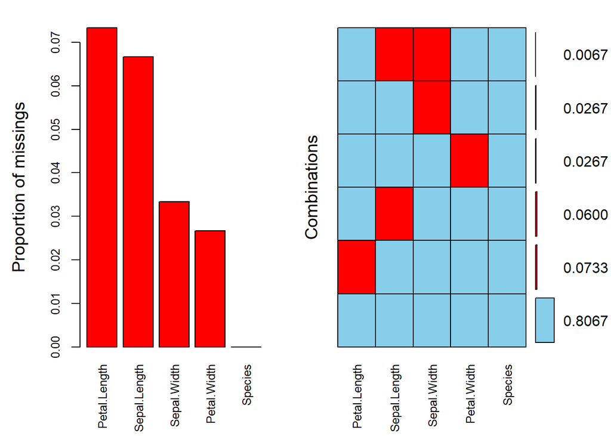

```
##
##  Variables sorted by number of missings:
##      Variable      Count
##  Petal.Length 0.07333333
##  Sepal.Length 0.06666667
##   Sepal.Width 0.03333333
##   Petal.Width 0.02666667
##       Species 0.00000000
```

```r
library(VIM)

vim.out<-aggr(iris_missing, numbers=T,sortVars=T, cex.axis=0.8)
```

```r
vim.out
```

```
##
##  Missings in variables:
##      Variable Count
##  Sepal.Length    10
##   Sepal.Width     5
##  Petal.Length    11
##   Petal.Width     4
```

여기서 numbers는 결측치의 빈도와 비율을 숫자로 표현해줄지 여부 입니다.

sortVars=T로 옵션을 주면 결측치가 많은 순서대로 결과가 출력됩니다.

마지막으로 축의 글자크기를 줄여 변수명이 그림으로 출력되도록 만들었습니다.

### 결측값 대체하기(mice)

무작위로 발생한 결측값들을 효과적으로 대체할 수 있는 기능 중 MICE 알고리즘(Multivariate Imputation by Chained Equation, 2011)을 기반으로 구현된 mice 패키지를 이용할 수 있다. mice 함수는 항목별로 적절한 알고리즘을 적용해 연속형 항목뿐 아니라 범주형 항목에 대해서도 결측값 대체를 지원하며 하나의 결측값에 대해 여러 개의 대체값을 제공함으로써 대체값이 모형에 주는 영향도를 줄여주는 MI(Multiple imputation) 기법을 적용할 수 있다.

```r
library(mice)
iris_mice <- mice(iris_missing, m=5, printFlag=F, seed=4123)
iris_mice$imp
```

```
## $Sepal.Length
##       1   2   3   4   5
## 1   4.9 5.0 5.4 5.2 5.0
## 4   5.4 4.9 4.8 5.0 4.9
## 9   4.7 4.4 5.0 4.4 4.9
## 23  4.7 4.9 5.0 4.7 4.9
## 69  5.7 5.7 5.6 5.6 5.5
## 82  5.6 5.5 5.1 5.5 5.1
## 99  5.0 4.8 4.8 5.0 5.1
## 106 7.2 7.7 7.9 7.3 7.7
## 117 6.4 6.9 5.8 6.9 6.7
## 121 6.2 6.4 6.8 6.5 6.3
##
## $Sepal.Width
##       1   2   3   4   5
```

[output cut: 30 more lines]

```r
iris_missing[!complete.cases(iris_missing),]
```

```
##     Sepal.Length Sepal.Width Petal.Length Petal.Width    Species
## 1             NA         3.5          1.4         0.2     setosa
## 4             NA         3.1          1.5         0.2     setosa
## 6            5.4         3.9           NA         0.4     setosa
## 9             NA         2.9          1.4         0.2     setosa
## 23            NA         3.6          1.0         0.2     setosa
## 28           5.2          NA          1.5         0.2     setosa
## 30           4.7         3.2           NA         0.2     setosa
## 37           5.5          NA          1.3         0.2     setosa
## 45           5.1         3.8           NA         0.4     setosa
## 56           5.7         2.8           NA         1.3 versicolor
## 60           5.2         2.7          3.9          NA versicolor
## 69            NA         2.2          4.5         1.5 versicolor
## 76           6.6         3.0          4.4          NA versicolor
## 82            NA         2.4          3.7         1.0 versicolor
## 83           5.8          NA          3.9         1.2 versicolor
## 86           6.0         3.4          4.5          NA versicolor
## 88           6.3         2.3           NA         1.3 versicolor
## 99            NA         2.5          3.0         1.1 versicolor
## 106           NA         3.0          6.6         2.1  virginica
## 109          6.7         2.5           NA         1.8  virginica
## 113          6.8          NA          5.5         2.1  virginica
## 117           NA          NA          5.5         1.8  virginica
## 121           NA         3.2          5.7         2.3  virginica
## 122          5.6         2.8           NA         2.0  virginica
## 125          6.7         3.3           NA         2.1  virginica
## 133          6.4         2.8          5.6          NA  virginica
## 134          6.3         2.8           NA         1.5  virginica
## 138          6.4         3.1           NA         1.8  virginica
## 147          6.3         2.5           NA         1.9  virginica
```

mice 함수 중 m은 대체값의 개수를 (기본값 : 5)

printFlag : 대체값 도출 시 발생하는 로그를 콘솔에 출력할지 여부

seed : 매번 실행하더라도 동일한 값이 나오도록 고정

그런데 결측값을 대체하기 위한 값이 하나면 될 것 같은데 왜 여러개의 대체값을 도출할까요?

대체값은 데이터 항목 간의 상관성을 고려한 다양한 알고리즘을 통해 얻어집니다. 얻어진 대체값들은 결국 실제로 측정된 값보다 통계적으로 더 그럴듯한 값들로 대체되므로 실제 측정값보다 분석모델에 더 큰 영향을 끼치게 됩니다. 이와 같은 왜곡을 줄이기 위해 여러개의 대체값을 구한 후, 각 데이터셋에 대해 분석 모형을 생성합니다.

예를 들어 5개의 데이터 셋으로 세운 5개의 분석모델들의 평균, 분산, 신뢰구건 등을 분석하여 그 결과를 통합(Pooling)한다면 대체값의 영향을 최소화한 모델을 얻을 수 있습니다.

```r
iris_imped_2 <- complete(iris_mice,2)
head(iris_imped_2, 10)
```

```
##    Sepal.Length Sepal.Width Petal.Length Petal.Width Species
## 1           5.0         3.5          1.4         0.2  setosa
## 2           4.9         3.0          1.4         0.2  setosa
## 3           4.7         3.2          1.3         0.2  setosa
## 4           4.9         3.1          1.5         0.2  setosa
## 5           5.0         3.6          1.4         0.2  setosa
## 6           5.4         3.9          1.3         0.4  setosa
## 7           4.6         3.4          1.4         0.3  setosa
## 8           5.0         3.4          1.5         0.2  setosa
## 9           4.4         2.9          1.4         0.2  setosa
## 10          4.9         3.1          1.5         0.1  setosa
```

```r
iris_imped_3 <- complete(iris_mice,3)
head(iris_imped_3, 10)
```

```
##    Sepal.Length Sepal.Width Petal.Length Petal.Width Species
## 1           5.4         3.5          1.4         0.2  setosa
## 2           4.9         3.0          1.4         0.2  setosa
## 3           4.7         3.2          1.3         0.2  setosa
## 4           4.8         3.1          1.5         0.2  setosa
## 5           5.0         3.6          1.4         0.2  setosa
## 6           5.4         3.9          1.4         0.4  setosa
## 7           4.6         3.4          1.4         0.3  setosa
## 8           5.0         3.4          1.5         0.2  setosa
## 9           5.0         2.9          1.4         0.2  setosa
## 10          4.9         3.1          1.5         0.1  setosa
```

complete 함수를 이용하면 대체그룹 중 하나를 지정해 결측값을 대체한 데이터셋을 만들 수 있습니다.

이 외에도 ’응용데이터분석’의 5장 결측값 대체(missing value imputation)을 읽으면 더 상세한 내용을 알 수 있습니다.

[figure not shown]